# Examen minería datos I

# 4.3.1 K vecinos

```r
#set.seed(123)
#fiveStats = function(...) c (twoClassSummary(...), defaultSummary(...))
#knnGrid <-  expand.grid(k  = 2:15)
#train.control <- trainControl(method = "repeatedcv", number = 10, repeats = 5, classProbs = TRUE, summaryFunction = #fiveStats)
#clusterCPU <- registerDoParallel(cores=detectCores() - 1)
#knn.fit <- train(Response ~ . ,
#             data = data.training,
#             method = "knn",
#             preProc = c("center", "scale"),
#             trControl = train.control,
#             metric = "ROC",
#              tuneGrid = knnGrid
#             )
#stopImplicitCluster()

#saveRDS(knn.fit, file = "knn.rds")
knn.fit <- readRDS(file = "knn.rds")
get_model_results(knn.fit, TRUE, TRUE)
```

```
## [1] "Resultados para cada uno de los parámetros de la malla:"
## k-Nearest Neighbors
##
## 2094 samples
##   48 predictor
##    2 classes: 'No', 'Yes'
##
## Pre-processing: centered (48), scaled (48)
## Resampling: Cross-Validated (10 fold, repeated 5 times)
## Summary of sample sizes: 1884, 1885, 1884, 1885, 1885, 1885, ...
## Resampling results across tuning parameters:
##
##   k   ROC        Sens       Spec       Accuracy   Kappa
##    2  0.9211128  0.7340952  0.9927546  0.8634194  0.7268370
##    3  0.9003571  0.6253938  0.9908388  0.8081122  0.6162197
##    4  0.8715186  0.5445971  0.9585476  0.7515748  0.5031412
##    5  0.8366230  0.4981813  0.9488187  0.7235009  0.4470011
##    6  0.8180606  0.4998919  0.9071978  0.7035391  0.4070851
##    7  0.8121026  0.5096447  0.8926795  0.7011504  0.4023150
##    8  0.8088074  0.5365678  0.8623150  0.6994292  0.3988732
##    9  0.8102971  0.5541575  0.8552473  0.7046879  0.4094002
##   10  0.8102678  0.5759414  0.8657271  0.7208192  0.4416622
##   11  0.8073287  0.5946300  0.8640238  0.7293205  0.4586449
##   12  0.8029591  0.5814487  0.8676410  0.7245454  0.4490831
##   13  0.8015668  0.5758993  0.8689835  0.7224419  0.4448771
##   14  0.7997882  0.5566136  0.8621209  0.7093678  0.4187346
##   15  0.7991813  0.5499194  0.8632564  0.7065918  0.4131781
##
## ROC was used to select the optimal model using the largest value.
## The final value used for the model was k = 2.
## [1] "#######################################################"
## [1] "Matriz de confusión del modelo:"
## [1] "#######################################################"
## Cross-Validated (10 fold, repeated 5 times) Confusion Matrix
##
## (entries are percentual average cell counts across resamples)
##
##           Reference
## Prediction   No  Yes
##        No  36.7  0.4
```

[output cut: 47 more lines]

```
## EmploymentStatusUnemployed      62.50
## Renew.Offer.TypeOffer4          57.69
## Renew.Offer.TypeOffer1          43.27
## Location.CodeRural              42.79
## Sales.ChannelBranch             41.83
## Marital.StatusSingle            35.58
## Location.CodeUrban              33.17
## Total.Claim.Amount              30.68
## Marital.StatusMarried           30.29
## Vehicle.SizeSmall               29.33
## Number.of.Policies              24.73
## Sales.ChannelCall Center        24.52
## month2011-02                    23.56
## month2011-01                    23.56
## [1] "Gráfico ROC-parámetros:"
```

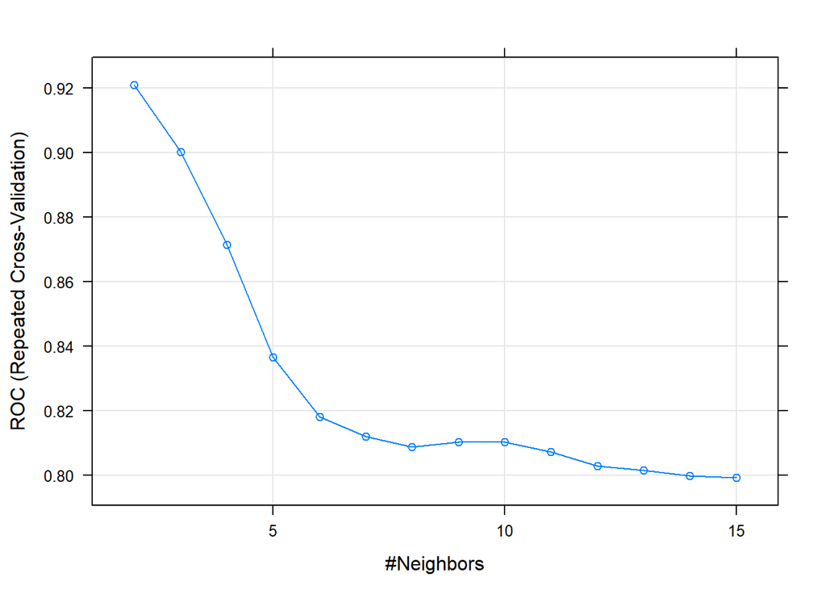

```
## [1] "Cruva ROC:"
```

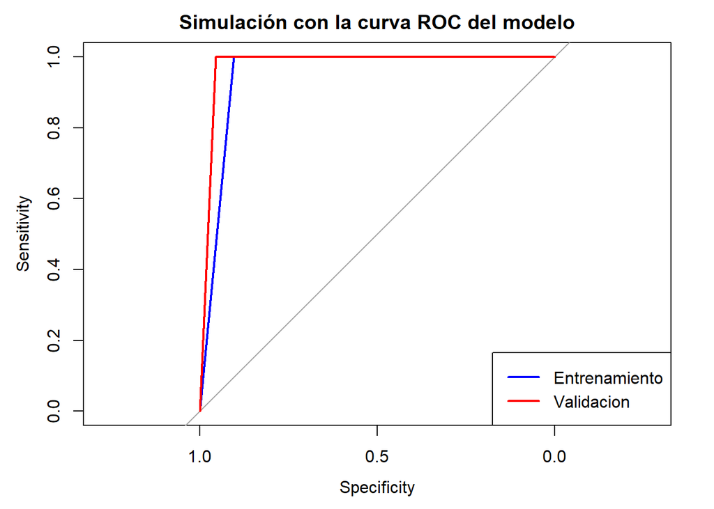

```r
plot_roc_curve(knn.fit)
```

# 4.3.2 kernel K vecinos

Aunque este método no se nos ha requerido, he considerado interesante probarlo, ya que usa una función kernel para transformar el espacio original, con lo que podemos intentar una separación no lineal en el espacio transformado.

```r
#set.seed(123)
#fiveStats = function(...) c (twoClassSummary(...), defaultSummary(...))
#kknnGrid <- expand.grid(kmax = 1:5,
#                        distance = 1:10,
#                        kernel = c('gaussian')
#                        )
#train.control <- trainControl(method = "repeatedcv", number = 10, repeats = 5, classProbs = TRUE, summaryFunction = #fiveStats)
#clusterCPU <- registerDoParallel(cores=detectCores() - 1)
#kknn.fit <- train(x = data.training[, names(data.training) != "Response"],
#             y = data.training$Response,
#             method = "kknn",
#             preProc = c("center", "scale"),
#             trControl = train.control,
#             metric = "ROC",
#              tuneGrid = kknnGrid
#             )
#stopImplicitCluster()

#saveRDS(kknn.fit, file = "kknn.rds")
kknn.fit <- readRDS(file = "kknn.rds")
get_model_results(kknn.fit, TRUE, TRUE)
```

```
## [1] "Resultados para cada uno de los parámetros de la malla:"
## k-Nearest Neighbors
##
## 2094 samples
##   48 predictor
##    2 classes: 'No', 'Yes'
##
## Pre-processing: centered (48), scaled (48)
## Resampling: Cross-Validated (10 fold, repeated 5 times)
## Summary of sample sizes: 1884, 1885, 1884, 1885, 1885, 1885, ...
## Resampling results across tuning parameters:
##
##   kmax  distance  ROC        Sens       Spec       Accuracy   Kappa
##   1      1        0.9213929  0.8433571  0.9994286  0.9213882  0.8427777
##   1      2        0.9233993  0.8473700  0.9994286  0.9233931  0.8467884
##   1      3        0.9208278  0.8422271  0.9994286  0.9208108  0.8416304
##   1      4        0.9237802  0.8481319  0.9994286  0.9237700  0.8475447
##   1      5        0.9236877  0.8479469  0.9994286  0.9236770  0.8473586
##   1      6        0.9244560  0.8494835  0.9994286  0.9244399  0.8488874
##   1      7        0.9238810  0.8483333  0.9994286  0.9238662  0.8477395
##   1      8        0.9224441  0.8454597  0.9994286  0.9224307  0.8448683
##   1      9        0.9196749  0.8399212  0.9994286  0.9196629  0.8393325
##   1     10        0.9191960  0.8389634  0.9994286  0.9191845  0.8383751
##   2      1        0.9213929  0.8433571  0.9994286  0.9213882  0.8427777
##   2      2        0.9233993  0.8473700  0.9994286  0.9233931  0.8467884
##   2      3        0.9208278  0.8422271  0.9994286  0.9208108  0.8416304
##   2      4        0.9237802  0.8481319  0.9994286  0.9237700  0.8475447
##   2      5        0.9236877  0.8479469  0.9994286  0.9236770  0.8473586
##   2      6        0.9244560  0.8494835  0.9994286  0.9244399  0.8488874
##   2      7        0.9238810  0.8483333  0.9994286  0.9238662  0.8477395
##   2      8        0.9224441  0.8454597  0.9994286  0.9224307  0.8448683
##   2      9        0.9196749  0.8399212  0.9994286  0.9196629  0.8393325
##   2     10        0.9191960  0.8389634  0.9994286  0.9191845  0.8383751
##   3      1        0.9213929  0.8433571  0.9994286  0.9213882  0.8427777
##   3      2        0.9233993  0.8473700  0.9994286  0.9233931  0.8467884
##   3      3        0.9208278  0.8422271  0.9994286  0.9208108  0.8416304
##   3      4        0.9237802  0.8481319  0.9994286  0.9237700  0.8475447
##   3      5        0.9236877  0.8479469  0.9994286  0.9236770  0.8473586
##   3      6        0.9244560  0.8494835  0.9994286  0.9244399  0.8488874
##   3      7        0.9238810  0.8483333  0.9994286  0.9238662  0.8477395
```

[output cut: 85 more lines]

```
## EmploymentStatusUnemployed      62.50
## Renew.Offer.TypeOffer4          57.69
## Renew.Offer.TypeOffer1          43.27
## Location.CodeRural              42.79
## Sales.ChannelBranch             41.83
## Marital.StatusSingle            35.58
## Location.CodeUrban              33.17
## Total.Claim.Amount              30.68
## Marital.StatusMarried           30.29
## Vehicle.SizeSmall               29.33
## Number.of.Policies              24.73
## Sales.ChannelCall Center        24.52
## month2011-02                    23.56
## month2011-01                    23.56
## [1] "Gráfico ROC-parámetros:"
```

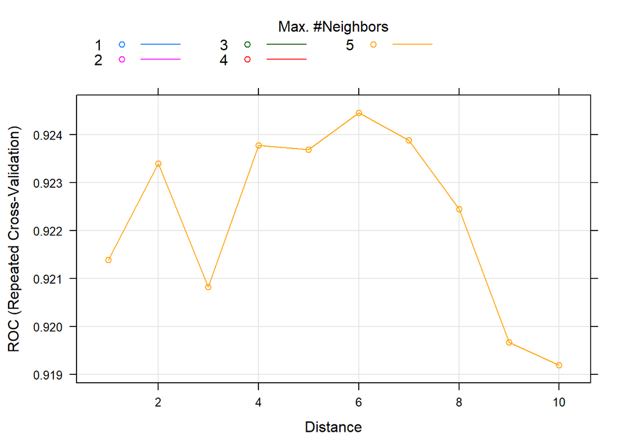

```
## [1] "Cruva ROC:"
```

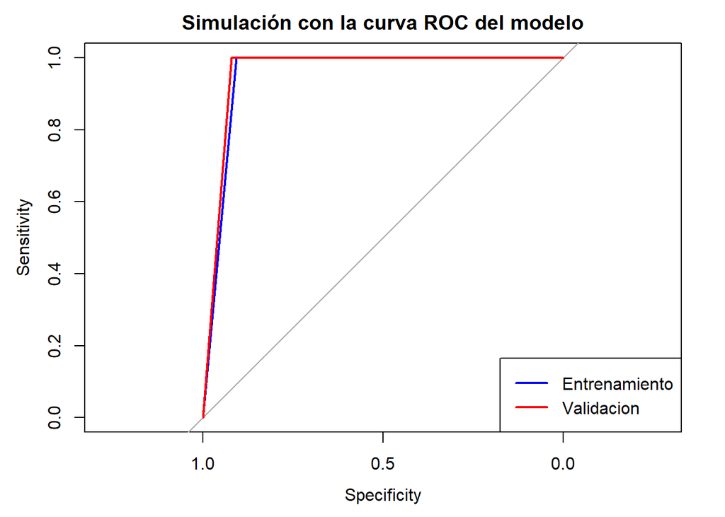

```r
plot_roc_curve(kknn.fit)
```

Como puede verse a la vista de los resultados, este algoritmo funciona mejor que el k-means, obteniendo una mejor separación del conjunto, tal y como nos indicaban los análisis gráficos.

# 4.4 Redes neuronales

```r
#set.seed(123)
#fiveStats = function(...) c (twoClassSummary(...), defaultSummary(...))
#nnGrid <-  expand.grid(size = 1:20)
#train.control <- trainControl(method = "repeatedcv", number = 10, repeats = 5, classProbs = TRUE, summaryFunction = #fiveStats)
#clusterCPU <- registerDoParallel(cores=detectCores() - 1)
#nn.fit <- train(x = data.training[, names(data.training) != "Response"],
#             y = data.training$Response,
#             method = "mlp",
#             preProc = c("center", "scale"),
#             trControl = train.control,
#             metric = "ROC",
#              tuneGrid = nnGrid
#             )
#stopImplicitCluster()

#saveRDS(nn.fit, file = "nn.rds")
nn.fit <-  readRDS(file = "nn.rds")
get_model_results(nn.fit, TRUE, TRUE)
```

```
## [1] "Resultados para cada uno de los parámetros de la malla:"
## Multi-Layer Perceptron
##
## 2094 samples
##   48 predictor
##    2 classes: 'No', 'Yes'
##
## Pre-processing: centered (48), scaled (48)
## Resampling: Cross-Validated (10 fold, repeated 5 times)
## Summary of sample sizes: 1884, 1885, 1884, 1885, 1885, 1885, ...
## Resampling results across tuning parameters:
##
##   size  ROC        Sens       Spec       Accuracy   Kappa
##    1    0.7722828  0.6858736  0.8491300  0.7675170  0.5350105
##    2    0.8296252  0.8060531  0.7342033  0.7701832  0.5403135
##    3    0.8551995  0.7350256  0.9121575  0.8235791  0.6471672
##    4    0.8773987  0.8030733  0.8746502  0.8388821  0.6777475
##    5    0.8889791  0.7757271  0.9390788  0.8574025  0.7147984
##    6    0.9015627  0.8176044  0.9350531  0.8763117  0.7526324
##    7    0.9132591  0.8131905  0.9598791  0.8865236  0.7730544
##    8    0.9245319  0.8255842  0.9717253  0.8986667  0.7973256
##    9    0.9335984  0.8416465  0.9761117  0.9088841  0.8177666
##   10    0.9377933  0.8399286  0.9856667  0.9127957  0.8255925
##   11    0.9423301  0.8433333  0.9877875  0.9155663  0.8311252
##   12    0.9510227  0.8542473  0.9902637  0.9222522  0.8445035
##   13    0.9532107  0.8544084  0.9889249  0.9216743  0.8433427
##   14    0.9528798  0.8578681  0.9868132  0.9223291  0.8446622
##   15    0.9585031  0.8600092  0.9919799  0.9259920  0.8519858
##   16    0.9598673  0.8617399  0.9906502  0.9261824  0.8523691
##   17    0.9621129  0.8683773  0.9906447  0.9295172  0.8590314
##   18    0.9621600  0.8681667  0.9917784  0.9299837  0.8599625
##   19    0.9678431  0.8670495  0.9931282  0.9300881  0.8601753
##   20    0.9693087  0.8697125  0.9931136  0.9314169  0.8628320
##
## ROC was used to select the optimal model using the largest value.
## The final value used for the model was size = 20.
## [1] "#######################################################"
## [1] "Matriz de confusión del modelo:"
## [1] "#######################################################"
## Cross-Validated (10 fold, repeated 5 times) Confusion Matrix
```

[output cut: 53 more lines]

```
## EmploymentStatusUnemployed      62.50
## Renew.Offer.TypeOffer4          57.69
## Renew.Offer.TypeOffer1          43.27
## Location.CodeRural              42.79
## Sales.ChannelBranch             41.83
## Marital.StatusSingle            35.58
## Location.CodeUrban              33.17
## Total.Claim.Amount              30.68
## Marital.StatusMarried           30.29
## Vehicle.SizeSmall               29.33
## Number.of.Policies              24.73
## Sales.ChannelCall Center        24.52
## month2011-02                    23.56
## month2011-01                    23.56
## [1] "Gráfico ROC-parámetros:"
```

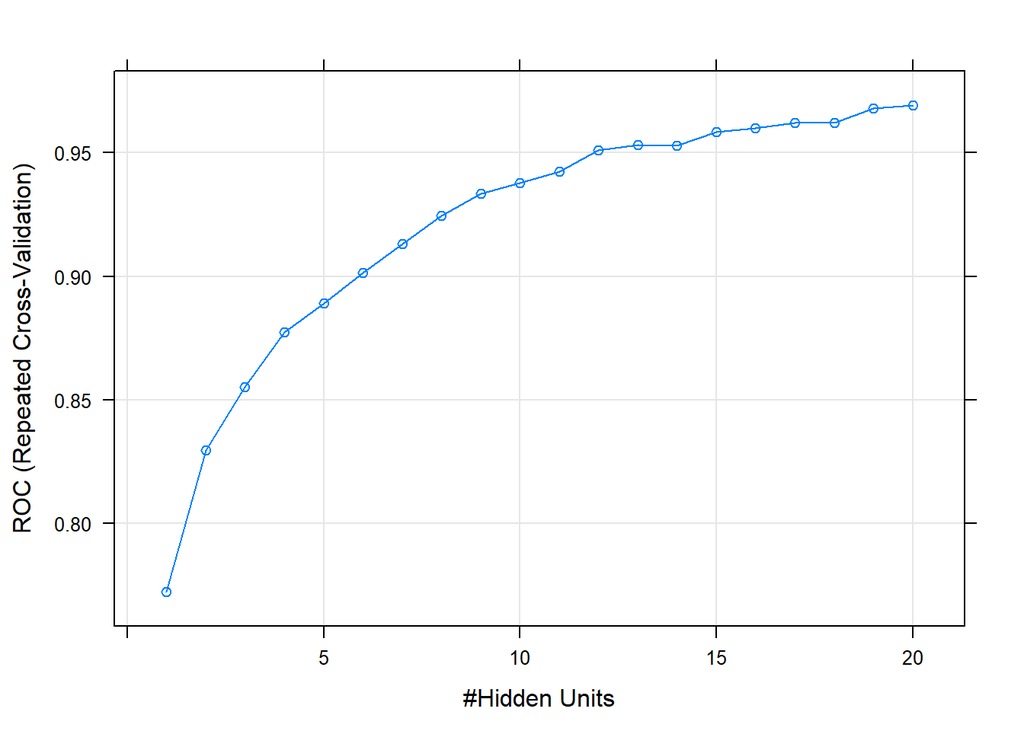

```
## [1] "Cruva ROC:"
```

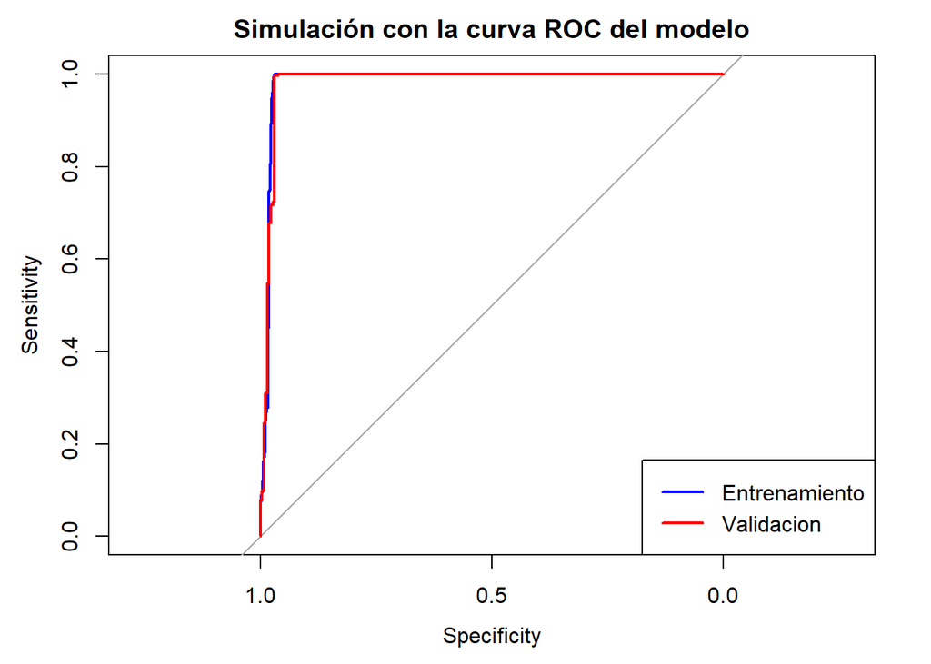

```r
plot_roc_curve(nn.fit)
```

# 4.5. Máquinas de vectores soporte

```r
#set.seed(123)
#fiveStats = function(...) c (twoClassSummary(...), defaultSummary(...))
#svmGrid <-  expand.grid(sigma = c(1:20)/40, C = c(.001, .01, .5))
#train.control <- trainControl(method = "repeatedcv", number = 10, repeats = 5, classProbs = TRUE, summaryFunction = #fiveStats)
#clusterCPU <- registerDoParallel(cores=detectCores() - 1)
#svm.fit <- train(x = data.training[, names(data.training) != "Response"],
#             y = data.training$Response,
#             method = "svmRadial",
#             preProc = c("center", "scale"),
#             trControl = train.control,
#             metric = "ROC",
#              tuneGrid = svmGrid
#             )
#stopImplicitCluster()

#saveRDS(svm.fit, file = "svm.rds")
svm.fit <-  readRDS(file = "svm.rds")
get_model_results(svm.fit, TRUE, FALSE)
```

```
## [1] "Resultados para cada uno de los parámetros de la malla:"
## Support Vector Machines with Radial Basis Function Kernel
##
## 2094 samples
##   48 predictor
##    2 classes: 'No', 'Yes'
##
## Pre-processing: centered (48), scaled (48)
## Resampling: Cross-Validated (10 fold, repeated 5 times)
## Summary of sample sizes: 1884, 1885, 1884, 1885, 1885, 1885, ...
## Resampling results across tuning parameters:
##
##   sigma  C      ROC        Sens       Spec       Accuracy   Kappa
##   0.025  0.001  0.8393900  0.6668608  0.6121886  0.6384721  0.2790495
##   0.025  0.010  0.8394029  0.6921832  0.6394176  0.6648849  0.3313784
##   0.025  0.500  0.9496142  0.8481172  0.9127216  0.8804150  0.7608309
##   0.050  0.001  0.9213858  0.7130458  0.6649853  0.6879629  0.3780311
##   0.050  0.010  0.9213858  0.7109377  0.6686264  0.6887294  0.3795641
##   0.050  0.500  0.9902692  0.9306813  0.9730751  0.9518658  0.9037340
##   0.075  0.001  0.9792816  0.7479615  0.7372454  0.7415508  0.4852070
##   0.075  0.010  0.9792926  0.7466172  0.7412747  0.7428933  0.4878919
##   0.075  0.500  0.9976399  0.9616154  0.9858700  0.9737287  0.9474591
##   0.100  0.001  0.9957406  0.7626502  0.7675678  0.7640563  0.5302179
##   0.100  0.010  0.9957387  0.7632234  0.7673791  0.7642487  0.5306026
##   0.100  0.500  0.9990755  0.9719304  0.9956099  0.9837602  0.9675212
##   0.125  0.001  0.9985609  0.7678004  0.7732985  0.7694968  0.5410989
##   0.125  0.010  0.9985536  0.7683700  0.7740678  0.7701662  0.5424377
##   0.125  0.500  0.9994036  0.9841575  0.9984762  0.9913087  0.9826177
##   0.150  0.001  0.9991736  0.7725678  0.7763553  0.7734089  0.5489231
##   0.150  0.010  0.9991681  0.7712363  0.7767344  0.7729327  0.5479707
##   0.150  0.500  0.9994839  0.9917875  0.9994286  0.9956044  0.9912089
##   0.175  0.001  0.9993012  0.7742839  0.7780769  0.7751278  0.5523608
##   0.175  0.010  0.9992994  0.7737125  0.7771154  0.7743613  0.5508278
##   0.175  0.500  0.9994911  0.9952289  0.9994286  0.9973256  0.9946512
##   0.200  0.001  0.9994179  0.7769505  0.7773077  0.7760765  0.5542582
##   0.200  0.010  0.9994179  0.7754267  0.7773077  0.7753146  0.5527344
##   0.200  0.500  0.9995367  0.9959908  0.9994286  0.9977074  0.9954149
##   0.225  0.001  0.9994492  0.7777125  0.7771154  0.7763613  0.5548278
##   0.225  0.010  0.9994492  0.7771410  0.7771154  0.7760756  0.5542564
##   0.225  0.500  0.9995202  0.9963736  0.9994286  0.9978984  0.9957968
```

[output cut: 63 more lines]

```
## EmploymentStatusUnemployed      62.50
## Renew.Offer.TypeOffer4          57.69
## Renew.Offer.TypeOffer1          43.27
## Location.CodeRural              42.79
## Sales.ChannelBranch             41.83
## Marital.StatusSingle            35.58
## Location.CodeUrban              33.17
## Total.Claim.Amount              30.68
## Marital.StatusMarried           30.29
## Vehicle.SizeSmall               29.33
## Number.of.Policies              24.73
## Sales.ChannelCall Center        24.52
## month2011-02                    23.56
## month2011-01                    23.56
## [1] "Gráfico ROC-parámetros:"
```

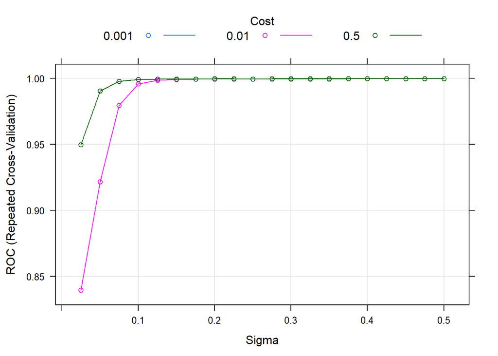

# 4.6. Boosting

```r
#set.seed(123)
#boostGrid <-  expand.grid(nIter = 1:20, method = c("Adaboost.M1", "Real adaboost"))
#fiveStats = function(...) c (twoClassSummary(...), defaultSummary(...))
#train.control <- trainControl(method = "repeatedcv", number = 10, repeats = 5, classProbs = TRUE, summaryFunction = #fiveStats)
#clusterCPU <- registerDoParallel(cores=detectCores() - 1)
#adaboost.fit <- train(x = data.training[, names(data.training) != "Response"],
#             y = data.training$Response,
#             method = "adaboost",
#             preProc = c("center", "scale"),
#             trControl = train.control,
#             metric = "ROC",
#              tuneGrid = boostGrid
#             )
#stopImplicitCluster()

#saveRDS(adaboost.fit, file = "adaboost.rds")
adaboost.fit <- readRDS(file = "adaboost.rds")
get_model_results(adaboost.fit, TRUE, TRUE)
```

```
## [1] "Resultados para cada uno de los parámetros de la malla:"
## AdaBoost Classification Trees
##
## 2094 samples
##   48 predictor
##    2 classes: 'No', 'Yes'
##
## Pre-processing: centered (48), scaled (48)
## Resampling: Cross-Validated (10 fold, repeated 5 times)
## Summary of sample sizes: 1884, 1885, 1884, 1885, 1885, 1885, ...
## Resampling results across tuning parameters:
##
##   nIter  method         ROC        Sens       Spec       Accuracy
##    1     Adaboost.M1    0.8312976  0.7816209  0.8809744  0.8313208
##    1     Real adaboost  0.7637272  0.7806685  0.8836502  0.8321788
##    2     Adaboost.M1    0.9071484  0.6456648  0.9933187  0.8194725
##    2     Real adaboost  0.8328053  0.8309304  0.9694542  0.9001787
##    3     Adaboost.M1    0.9391314  0.8311190  0.9780366  0.9045751
##    3     Real adaboost  0.8289873  0.8750659  0.9994286  0.9372428
##    4     Adaboost.M1    0.9624846  0.7512619  0.9984762  0.8748749
##    4     Real adaboost  0.8356068  0.9012271  0.9994286  0.9503297
##    5     Adaboost.M1    0.9737669  0.8586136  0.9977143  0.9281660
##    5     Real adaboost  0.8435434  0.9182216  0.9994286  0.9588241
##    6     Adaboost.M1    0.9827590  0.8011062  0.9994286  0.9002721
##    6     Real adaboost  0.8542414  0.9350165  0.9994286  0.9672297
##    7     Adaboost.M1    0.9874890  0.8775513  0.9994286  0.9384882
##    7     Real adaboost  0.8526197  0.9430513  0.9994286  0.9712425
##    8     Adaboost.M1    0.9907542  0.8280678  0.9994286  0.9137463
##    8     Real adaboost  0.8514742  0.9514451  0.9994286  0.9754430
##    9     Adaboost.M1    0.9929127  0.8926319  0.9994286  0.9460330
##    9     Real adaboost  0.8637531  0.9585183  0.9994286  0.9789824
##   10     Adaboost.M1    0.9941984  0.8517509  0.9994286  0.9255946
##   10     Real adaboost  0.8711917  0.9635073  0.9994286  0.9814718
##   11     Adaboost.M1    0.9954679  0.9016081  0.9994286  0.9505215
##   11     Real adaboost  0.8692051  0.9659890  0.9994286  0.9827099
##   12     Adaboost.M1    0.9958364  0.8725769  0.9994286  0.9360056
##   12     Real adaboost  0.8691389  0.9677088  0.9994286  0.9835707
##   13     Adaboost.M1    0.9965776  0.9086667  0.9994286  0.9540549
##   13     Real adaboost  0.8709498  0.9696136  0.9994286  0.9845258
##   14     Adaboost.M1    0.9968601  0.8859377  0.9994286  0.9426874
```

[output cut: 115 more lines]

```
## EmploymentStatusUnemployed      62.50
## Renew.Offer.TypeOffer4          57.69
## Renew.Offer.TypeOffer1          43.27
## Location.CodeRural              42.79
## Sales.ChannelBranch             41.83
## Marital.StatusSingle            35.58
## Location.CodeUrban              33.17
## Total.Claim.Amount              30.68
## Marital.StatusMarried           30.29
## Vehicle.SizeSmall               29.33
## Number.of.Policies              24.73
## Sales.ChannelCall Center        24.52
## month2011-02                    23.56
## month2011-01                    23.56
## [1] "Gráfico ROC-parámetros:"
```

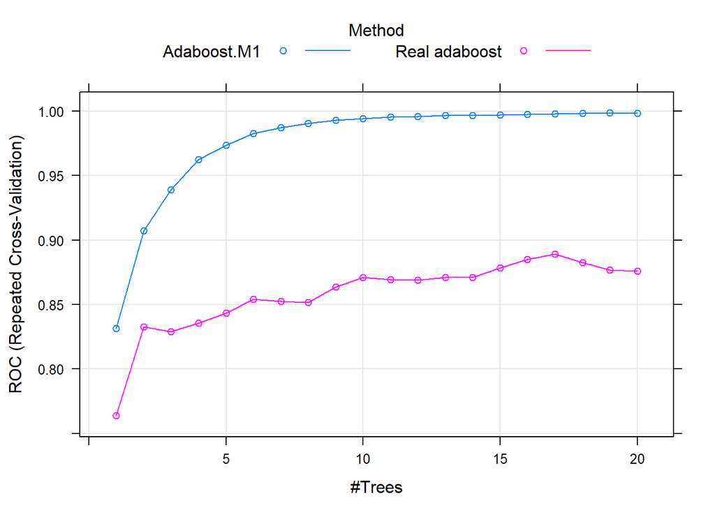

```
## [1] "Cruva ROC:"
```

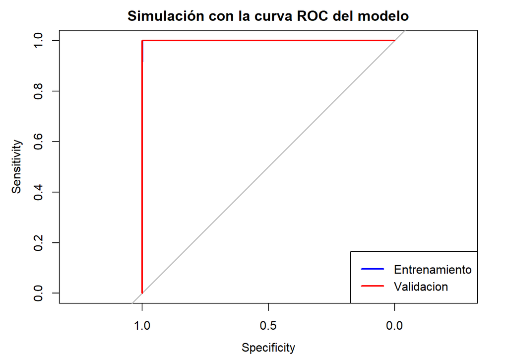

```r
plot_roc_curve(adaboost.fit)
```

# 4.7. Bagging

```r
#set.seed(123)
#fiveStats = function(...) c (twoClassSummary(...), defaultSummary(...))
#train.control <- trainControl(method = "repeatedcv", number = 10, repeats = 5, classProbs = TRUE, summaryFunction = #fiveStats)
#clusterCPU <- registerDoParallel(cores=detectCores() - 1)
#bag.fit <- train(x = data.training[, names(data.training) != "Response"],
#             y = data.training$Response,
#             method = "treebag",
#             preProc = c("center", "scale"),
#             trControl = train.control,
#             metric = "ROC"
#             #tuneGrid = bagGrid
#             )
#stopImplicitCluster()


#saveRDS(bag.fit, file = "bag.rds")
bag.fit <- readRDS(file = "bag.rds")
get_model_results(bag.fit, FALSE, TRUE)
```

```
## [1] "Resultados para cada uno de los parámetros de la malla:"
## Bagged CART
##
## 2094 samples
##   48 predictor
##    2 classes: 'No', 'Yes'
##
## Pre-processing: centered (48), scaled (48)
## Resampling: Cross-Validated (10 fold, repeated 5 times)
## Summary of sample sizes: 1884, 1885, 1884, 1885, 1885, 1885, ...
## Resampling results:
##
##   ROC        Sens       Spec       Accuracy   Kappa
##   0.9974609  0.9077125  0.9990476  0.9533782  0.9067562
##
## [1] "#######################################################"
## [1] "Matriz de confusión del modelo:"
## [1] "#######################################################"
## Cross-Validated (10 fold, repeated 5 times) Confusion Matrix
##
## (entries are percentual average cell counts across resamples)
##
##           Reference
## Prediction   No  Yes
##        No  45.4  0.0
##        Yes  4.6 50.0
##
##  Accuracy (average) : 0.9534
##
## [1] "#######################################################"
## [1] "Matriz de confusión comparando las predicciones del modelo y los datos de test:"
## [1] "#######################################################"
## Confusion Matrix and Statistics
##
##           Reference
## Prediction  No Yes
##        No  253   0
##        Yes   8 261
##
##                Accuracy : 0.9847
```

[output cut: 31 more lines]

```
## Months.Since.Last.Claim         68.78
## Renew.Offer.TypeOffer4          45.41
## EmploymentStatusRetired         42.53
## Renew.Offer.TypeOffer2          34.93
## Marital.StatusDivorced          33.95
## Location.CodeSuburban           32.56
## Sales.ChannelAgent              31.77
## Renew.Offer.TypeOffer3          30.58
## Number.of.Policies              28.99
## Number.of.Open.Complaints       19.91
## EmploymentStatusUnemployed      19.55
## Renew.Offer.TypeOffer1          19.34
## EducationBachelor               16.94
## Marital.StatusMarried           15.45
## Marital.StatusSingle            14.49
```

```
## [1] "Cruva ROC:"
```

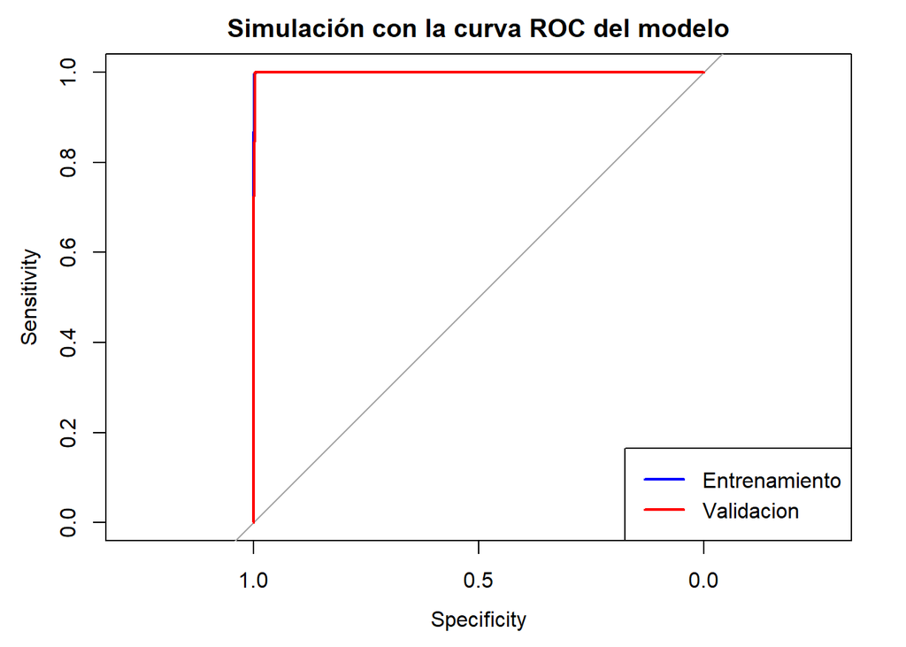

```r
plot_roc_curve(bag.fit)
```

# 5. Contraste de modelos

Realizamos la comparación de los distintos modelos.

```r
# Se excluye bagging
modelos <- list(C5.0 = c5_0.fit, RF = rf.fit, KNN = knn.fit, KKNN = kknn.fit,MLP = nn.fit, SVM = svm.fit, ADABOOST = adaboost.fit, BAG=bag.fit)
resultados <- resamples(modelos)
resultados
```

```
##
## Call:
## resamples.default(x = modelos)
##
## Models: C5.0, RF, KNN, KKNN, MLP, SVM, ADABOOST, BAG
## Number of resamples: 50
## Performance metrics: Accuracy, Kappa, ROC, Sens, Spec
## Time estimates for: everything, final model fit
```

```r
summary(resultados)
```

```
##
## Call:
## summary.resamples(object = resultados)
##
## Models: C5.0, RF, KNN, KKNN, MLP, SVM, ADABOOST, BAG
## Number of resamples: 50
##
## Accuracy
##               Min.   1st Qu.    Median      Mean   3rd Qu.      Max. NA's
## C5.0     0.9619048 0.9760766 0.9809524 0.9815693 0.9857143 0.9952381    0
## RF       0.9569378 0.9759903 0.9808152 0.9788885 0.9844725 1.0000000    0
## KNN      0.8238095 0.8516746 0.8660287 0.8634194 0.8803828 0.9000000    0
## KKNN     0.8947368 0.9095238 0.9238095 0.9244399 0.9366826 0.9619048    0
## MLP      0.8904762 0.9235361 0.9333333 0.9314169 0.9427888 0.9666667    0
## SVM      0.9712919 0.9952381 1.0000000 0.9977074 1.0000000 1.0000000    0
## ADABOOST 0.9285714 0.9523810 0.9617225 0.9598822 0.9666667 0.9904306    0
## BAG      0.9186603 0.9473684 0.9523810 0.9533782 0.9619048 0.9904762    0
##
## Kappa
##               Min.   1st Qu.    Median      Mean   3rd Qu.      Max. NA's
## C5.0     0.9238095 0.9521443 0.9619048 0.9631391 0.9714286 0.9904762    0
## RF       0.9138618 0.9519776 0.9616265 0.9577773 0.9689416 1.0000000    0
## KNN      0.6476190 0.7031926 0.7323821 0.7268370 0.7604859 0.8000000    0
## KKNN     0.7893145 0.8190476 0.8476190 0.8488874 0.8733075 0.9238095    0
## MLP      0.7809524 0.8471432 0.8666667 0.8628320 0.8855874 0.9333333    0
## SVM      0.9425824 0.9904762 1.0000000 0.9954149 1.0000000 1.0000000    0
## ADABOOST 0.8571429 0.9047619 0.9234432 0.9197646 0.9333333 0.9808626    0
## BAG      0.8374434 0.8946814 0.9047619 0.9067562 0.9238095 0.9809524    0
##
## ROC
##               Min.   1st Qu.    Median      Mean   3rd Qu.      Max. NA's
## C5.0     0.9856689 0.9962971 0.9995879 0.9975104 1.0000000 1.0000000    0
## RF       0.9927198 1.0000000 1.0000000 0.9998015 1.0000000 1.0000000    0
## KNN      0.8809524 0.9095238 0.9234432 0.9211128 0.9328640 0.9571429    0
## KKNN     0.8943681 0.9095238 0.9238095 0.9244560 0.9364583 0.9619048    0
## MLP      0.9311565 0.9623450 0.9705172 0.9693087 0.9799734 0.9996337    0
## SVM      0.9785714 1.0000000 1.0000000 0.9995367 1.0000000 1.0000000    0
## ADABOOST 0.9879121 0.9996346 1.0000000 0.9986657 1.0000000 1.0000000    0
## BAG      0.9858050 0.9948648 0.9992031 0.9974609 0.9999542 1.0000000    0
##
## Sens
##               Min.   1st Qu.    Median      Mean   3rd Qu.      Max. NA's
## C5.0     0.9238095 0.9520375 0.9619048 0.9637234 0.9784341 0.9904762    0
## RF       0.9238095 0.9519231 0.9615385 0.9583590 0.9688416 1.0000000    0
## KNN      0.6666667 0.7047619 0.7403846 0.7340952 0.7613324 0.8000000    0
## KKNN     0.7980769 0.8190476 0.8476190 0.8494835 0.8729167 0.9238095    0
## MLP      0.7809524 0.8557692 0.8755952 0.8697125 0.8921016 0.9333333    0
## SVM      0.9711538 0.9904762 1.0000000 0.9959908 1.0000000 1.0000000    0
## ADABOOST 0.8571429 0.9047619 0.9238095 0.9203388 0.9333333 0.9809524    0
## BAG      0.8380952 0.8942308 0.9047619 0.9077125 0.9238095 0.9809524    0
##
## Spec
##               Min.   1st Qu. Median      Mean 3rd Qu. Max. NA's
## C5.0     0.9714286 1.0000000      1 0.9994286       1    1    0
## RF       0.9714286 1.0000000      1 0.9994286       1    1    0
## KNN      0.9619048 0.9903846      1 0.9927546       1    1    0
## KKNN     0.9714286 1.0000000      1 0.9994286       1    1    0
## MLP      0.9519231 0.9904762      1 0.9931136       1    1    0
## SVM      0.9714286 1.0000000      1 0.9994286       1    1    0
## ADABOOST 0.9714286 1.0000000      1 0.9994286       1    1    0
## BAG      0.9714286 1.0000000      1 0.9990476       1    1    0
```

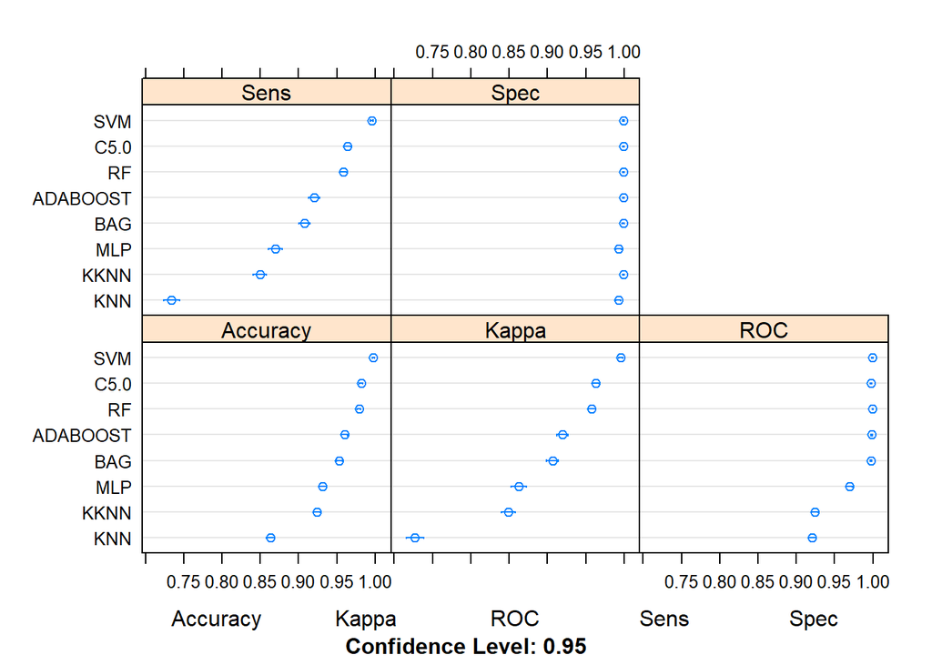

```r
dotplot(resultados)
```

```r
diferencias <- diff(resultados)
summary(diferencias)
```

```
##
## Call:
## summary.diff.resamples(object = diferencias)
##
## p-value adjustment: bonferroni
## Upper diagonal: estimates of the difference
## Lower diagonal: p-value for H0: difference = 0
##
## Accuracy
##          C5.0      RF        KNN       KKNN      MLP       SVM
## C5.0                0.002681  0.118150  0.057129  0.050152 -0.016138
## RF       1.0000               0.115469  0.054449  0.047472 -0.018819
## KNN      < 2.2e-16 < 2.2e-16           -0.061020 -0.067998 -0.134288
## KKNN     < 2.2e-16 < 2.2e-16 < 2.2e-16           -0.006977 -0.073268
## MLP      < 2.2e-16 < 2.2e-16 < 2.2e-16 0.2831              -0.066291
## SVM      1.381e-15 < 2.2e-16 < 2.2e-16 < 2.2e-16 < 2.2e-16
## ADABOOST 1.327e-13 2.186e-12 < 2.2e-16 < 2.2e-16 2.580e-11 < 2.2e-16
## BAG      5.245e-15 2.652e-15 < 2.2e-16 2.935e-12 5.206e-08 < 2.2e-16
##          ADABOOST  BAG
## C5.0      0.021687  0.028191
## RF        0.019006  0.025510
## KNN      -0.096463 -0.089959
## KKNN     -0.035442 -0.028938
## MLP      -0.028465 -0.021961
## SVM       0.037825  0.044329
## ADABOOST            0.006504
## BAG      0.1178
##
## Kappa
##          C5.0      RF        KNN       KKNN      MLP       SVM
## C5.0                0.005362  0.236302  0.114252  0.100307 -0.032276
## RF       1.0000               0.230940  0.108890  0.094945 -0.037638
## KNN      < 2.2e-16 < 2.2e-16           -0.122050 -0.135995 -0.268578
## KKNN     < 2.2e-16 < 2.2e-16 < 2.2e-16           -0.013945 -0.146528
## MLP      < 2.2e-16 < 2.2e-16 < 2.2e-16 0.2847              -0.132583
## SVM      1.381e-15 < 2.2e-16 < 2.2e-16 < 2.2e-16 < 2.2e-16
## ADABOOST 1.327e-13 2.181e-12 < 2.2e-16 < 2.2e-16 2.568e-11 < 2.2e-16
## BAG      5.264e-15 2.659e-15 < 2.2e-16 2.927e-12 5.211e-08 < 2.2e-16
##          ADABOOST  BAG
## C5.0      0.043374  0.056383
```

[output cut: 52 more lines]

```
## KNN      0.001103 0.001103            -0.006674 -0.000359 -0.006674
## KKNN     NA       NA        0.001103             0.006315  0.000000
## MLP      0.005879 0.005879  1.000000  0.005879            -0.006315
## SVM      NA       NA        0.001103  NA        0.005879
## ADABOOST NA       NA        0.001103  NA        0.005879  NA
## BAG      1.000000 1.000000  0.001361  1.000000  0.010815  1.000000
##          ADABOOST  BAG
## C5.0      0.000000  0.000381
## RF        0.000000  0.000381
## KNN      -0.006674 -0.006293
## KKNN      0.000000  0.000381
## MLP      -0.006315 -0.005934
## SVM       0.000000  0.000381
## ADABOOST            0.000381
## BAG      1.000000
```

A tenor de los resultados, los mejores métodos son, en orden (usando como criterios la curva ROC y el índice Kappa):

1. Máquinas de vectores soporte
2. C5.0 y random forest
3. Adaboost y Bag
4. Redes reuronales y kernel k-means
5. k-means

## 6. Tablas resumen con las métricas

Por último, mostramos una matriz resumen con todas las métricas, usando la función proporcionada por los profesores:

```r
Result <- function ( modelos ){
  n_modelos = length(modelos)
  comparativa <- matrix(0, n_modelos, 7)
  pred <- NULL

  for (i in 1:n_modelos){
    pred[[i]] <- predict(modelos[i], data.testing, type="prob")
    comparativa[i,1] = modelos[[i]]$method
    if (modelos[[i]]$method == "treebag"){
       comparativa[i,2] = "-"
       comparativa[i,3] = "-"
       comparativa[i,4] = "-"
       comparativa[i,5] = modelos[[i]]$results$Accuracy
       comparativa[i,6] = modelos[[i]]$results$Kappa
    }else{
       comparativa[i,2] = modelos[[i]]$results[rownames(modelos[[i]]$bestTune), c("ROC")]
       comparativa[i,3] = modelos[[i]]$results[rownames(modelos[[i]]$bestTune), c("Sens")]
       comparativa[i,4] = modelos[[i]]$results[rownames(modelos[[i]]$bestTune), c("Spec")]
       comparativa[i,5] = modelos[[i]]$results[rownames(modelos[[i]]$bestTune), c("Accuracy")]
       comparativa[i,6] = modelos[[i]]$results[rownames(modelos[[i]]$bestTune), c("Kappa")]
    }
    comparativa[i,7] = auc(roc(data.testing$Response,pred[[i]][[1]][,"Yes"]))
  }
  colnames(comparativa) <- c("Modelo", "ROC", "Sens", "Spec", "Accuracy", "Kappa", "ROC Validación")
  return(comparativa)
}

modelos <- list(C5.0 = c5_0.fit, RF = rf.fit, KNN = knn.fit, KKNN = kknn.fit,MLP = nn.fit, ADABOOST = adaboost.fit, BAG=bag.fit)
Result(modelos)
```

```
##      Modelo     ROC                 Sens
## [1,] "C5.0"     "0.997510382367937" "0.963723443223443"
## [2,] "parRF"    "0.999801525580646" "0.958358974358974"
## [3,] "knn"      "0.921112831498477" "0.734095238095238"
## [4,] "kknn"     "0.924456043956044" "0.849483516483516"
## [5,] "mlp"      "0.969308678836426" "0.869712454212454"
## [6,] "adaboost" "0.998665738336755" "0.920338827838828"
## [7,] "treebag"  "-"                 "-"
##      Spec                Accuracy            Kappa
## [1,] "0.999428571428571" "0.981569299121931" "0.963139057862969"
## [2,] "0.999428571428571" "0.978888484322695" "0.957777344606569"
## [3,] "0.992754578754579" "0.863419365721997" "0.726837039314734"
## [4,] "0.999428571428571" "0.924439858387227" "0.848887360882125"
## [5,] "0.993113553113553" "0.931416903272166" "0.862832036020149"
## [6,] "0.999428571428571" "0.959882249329618" "0.919764607196278"
## [7,] "-"                 "0.953378244562455" "0.906756158279186"
##      ROC Validación
## [1,] "0.997372322778585"
## [2,] "1"
## [3,] "0.977011494252874"
## [4,] "0.959770114942529"
## [5,] "0.982354927261784"
## [6,] "1"
## [7,] "0.999405469678954"
```